# CA - S10: Churn Analysis

Josep Curto, IE Business School

Tháng 2 16, 2021

Abstract

This technical note introduces how to calculate churn analysis with R.

# Understanding churn evolution

## Our case

- Our scenario: company with a subscription business model created one year ago
- A user pays 5 euros per month to access the service.
- Some users abandoned the service after some months.
- We need to know what is happening.
- We don’t have a lot of data, but we need to run some analysis and understand the evolution.
- We will use *survival analysis* based on [Kaplan-Meier Estimators](https://en.wikipedia.org/wiki/Kaplan–Meier_estimator).

## Load packages

```r
# Cleaning the environment
rm(list=ls())

# List of packages for session
.packages <- c("ggplot2","survival","GGally","scales","survminer")

# Install CRAN packages (if not already installed)
.inst <- .packages %in% installed.packages()
if(length(.packages[!.inst]) > 0) install.packages(.packages[!.inst])

# Load packages into session
suppressPackageStartupMessages(invisible(lapply(.packages, library, character.only = TRUE)))
```

```r
library(ggplot2)
library(survival)
library(GGally)
library(scales)
library(survminer)
```

## Loading data

First, we load the data. We have four variables: gender (0 means male, 1 means female), start (refers to the day of the year when the customer started the subscription), time (refers to the amount of days where the customer was active since the start day) and churned (0 means no churned and 1 means churned).

```r
(df <- read.csv('data/s10-1.csv'))
```

| gender | start | time | churned |
| --- | --- | --- | --- |
| 0 | 92 | 273 | 0 |
| 0 | 5 | 360 | 0 |
| 0 | 357 | 8 | 0 |
| 0 | 154 | 211 | 0 |
| 0 | 118 | 247 | 0 |
| 1 | 308 | 57 | 0 |
| 0 | 275 | 90 | 0 |
| 0 | 307 | 58 | 0 |
| 0 | 313 | 52 | 0 |
| 0 | 353 | 12 | 0 |

[output cut: 65 more lines]

**Question: Do we have some insights from data exploration?**

## The Kaplan–Meier estimator

The **Kaplan–Meier estimator**, also known as the product limit estimator, is a non-parametric statistic used to estimate the survival function from lifetime data. In medical research, it is often used to measure the fraction of patients living for a certain amount of time after treatment.

## Analysis

We will use Survival Analysis based on Kaplan-Meier estimators. Let’s create a survival object and churned == 1 represents that the customer is no longer subscribed.

| gender | start | time | churned | SurvObj |
| --- | --- | --- | --- | --- |
| 0 | 92 | 273 | 0 | 273+ |
| 0 | 5 | 360 | 0 | 360+ |
| 0 | 357 | 8 | 0 | 8+ |
| 0 | 154 | 211 | 0 | 211+ |
| 0 | 118 | 247 | 0 | 247+ |
| 1 | 308 | 57 | 0 | 57+ |
| 0 | 275 | 90 | 0 | 90+ |
| 0 | 307 | 58 | 0 | 58+ |
| 0 | 313 | 52 | 0 | 52+ |
| 0 | 353 | 12 | 0 | 12+ |

[output cut: 65 more lines]

Let’s create the Kaplan-Meier estimator. The “log” confidence interval is preferred.

```r
(km.as.one <- survfit(SurvObj ~ 1, data = df, conf.type = "log", conf.int=0.95))
```

```
Call: survfit(formula = SurvObj ~ 1, data = df, conf.type = "log",
    conf.int = 0.95)

      n  events  median 0.95LCL 0.95UCL
   9254    1081      NA      NA      NA
```

Let’s review the structure of our new object:

```r
str(km.as.one)
```

```
List of 16
 $ n        : int 9254
 $ time     : num [1:366] 0 1 2 3 4 5 6 7 8 9 ...
 $ n.risk   : num [1:366] 9254 9230 9197 9164 9131 ...
 $ n.event  : num [1:366] 0 9 8 4 5 6 8 7 2 7 ...
 $ n.censor : num [1:366] 24 24 25 29 29 30 20 17 24 28 ...
 $ surv     : num [1:366] 1 0.999 0.998 0.998 0.997 ...
 $ std.err  : num [1:366] 0 0.000325 0.000448 0.000498 0.000555 ...
 $ cumhaz   : num [1:366] 0 0.000975 0.001845 0.002281 0.002829 ...
 $ std.chaz : num [1:366] 0 0.000325 0.000447 0.000498 0.000555 ...
 $ type     : chr "right"
 $ logse    : logi TRUE
 $ conf.int : num 0.95
 $ conf.type: chr "log"
 $ lower    : num [1:366] 1 0.998 0.997 0.997 0.996 ...
 $ upper    : num [1:366] 1 1 0.999 0.999 0.998 ...
 $ call     : language survfit(formula = SurvObj ~ 1, data = df, conf.type = "log", conf.int = 0.95)
 - attr(*, "class")= chr "survfit"
```

Let’s review what he have created. This is the curve:

```r
summary(km.as.one)
```

```
Call: survfit(formula = SurvObj ~ 1, data = df, conf.type = "log",
    conf.int = 0.95)

 time n.risk n.event survival  std.err lower 95% CI upper 95% CI
    1   9230       9    0.999 0.000325        0.998        1.000
    2   9197       8    0.998 0.000447        0.997        0.999
    3   9164       4    0.998 0.000497        0.997        0.999
    4   9131       5    0.997 0.000553        0.996        0.998
    5   9097       6    0.997 0.000615        0.995        0.998
    6   9061       8    0.996 0.000688        0.994        0.997
    7   9033       7    0.995 0.000747        0.993        0.996
    8   9009       2    0.995 0.000763        0.993        0.996
    9   8983       7    0.994 0.000817        0.992        0.995
   10   8948       4    0.993 0.000846        0.992        0.995
 [ reached getOption("max.print") -- omitted 299 rows ]
```

Let’s create a graph:

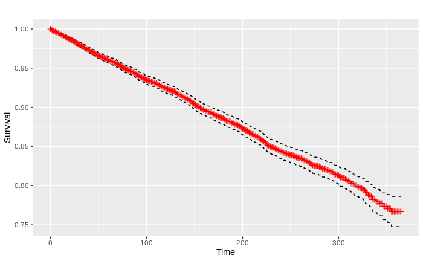

```r
ggsurv(km.as.one)
```

Let’s improve the graph with title and labels for the axis:

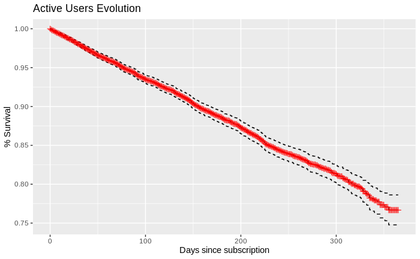

```r
ggsurv(km.as.one, xlab = 'Days since subscription', ylab = '% Survival', main='Active Users Evolution')
```

**Question: what is happening?**

It is worth noticing that we have two groups (based on gender). This is called **Multiple Stratum** and we can generate the analysis for both groups and compare:

```r
(km.by.gender <- survfit(SurvObj ~ gender, data = df, conf.type = "log", conf.int=0.95))
```

```
Call: survfit(formula = SurvObj ~ gender, data = df, conf.type = "log",
    conf.int = 0.95)

            n events median 0.95LCL 0.95UCL
gender=0 6722    830     NA      NA      NA
gender=1 2532    251     NA      NA      NA
```

We need to know the structure of our new object:

```r
str(km.by.gender)
```

```
List of 17
 $ n        : int [1:2] 6722 2532
 $ time     : num [1:731] 0 1 2 3 4 5 6 7 8 9 ...
 $ n.risk   : num [1:731] 6722 6704 6678 6656 6631 ...
 $ n.event  : num [1:731] 0 9 6 4 2 5 7 5 1 3 ...
 $ n.censor : num [1:731] 18 17 16 21 20 22 16 13 20 23 ...
 $ surv     : num [1:731] 1 0.999 0.998 0.997 0.997 ...
 $ std.err  : num [1:731] 0 0.000448 0.000579 0.000652 0.000686 ...
 $ cumhaz   : num [1:731] 0 0.00134 0.00224 0.00284 0.00314 ...
 $ std.chaz : num [1:731] 0 0.000447 0.000579 0.000652 0.000686 ...
 $ strata   : Named int [1:2] 366 365
  ..- attr(*, "names")= chr [1:2] "gender=0" "gender=1"
 $ type     : chr "right"
 $ logse    : logi TRUE
 $ conf.int : num 0.95
 $ conf.type: chr "log"
 $ lower    : num [1:731] 1 0.998 0.997 0.996 0.996 ...
 $ upper    : num [1:731] 1 1 0.999 0.998 0.998 ...
 $ call     : language survfit(formula = SurvObj ~ gender, data = df, conf.type = "log", conf.int = 0.95)
 - attr(*, "class")= chr "survfit"
```

Let’s review the survival curve:

```r
summary(km.by.gender)
```

```
Call: survfit(formula = SurvObj ~ gender, data = df, conf.type = "log",
    conf.int = 0.95)

                gender=0
 time n.risk n.event survival  std.err lower 95% CI upper 95% CI
    1   6704       9    0.999 0.000447        0.998        1.000
    2   6678       6    0.998 0.000578        0.997        0.999
    3   6656       4    0.997 0.000650        0.996        0.998
    4   6631       2    0.997 0.000684        0.996        0.998
    5   6609       5    0.996 0.000762        0.995        0.998
    6   6582       7    0.995 0.000860        0.993        0.997
    7   6559       5    0.994 0.000924        0.992        0.996
    8   6541       1    0.994 0.000936        0.992        0.996
    9   6520       3    0.994 0.000972        0.992        0.996
   10   6494       2    0.993 0.000996        0.991        0.995
 [ reached getOption("max.print") -- omitted 277 rows ]

                gender=1
 time n.risk n.event survival  std.err lower 95% CI upper 95% CI
    2   2519       2    0.999 0.000561        0.998        1.000
    4   2500       3    0.998 0.000890        0.996        1.000
    5   2488       1    0.998 0.000976        0.996        1.000
    6   2479       1    0.997 0.001056        0.995        0.999
    7   2474       2    0.996 0.001199        0.994        0.999
    8   2468       1    0.996 0.001264        0.994        0.998
    9   2463       4    0.994 0.001499        0.991        0.997
   10   2454       2    0.994 0.001603        0.990        0.997
   12   2440       2    0.993 0.001702        0.989        0.996
   14   2420       1    0.992 0.001750        0.989        0.996
 [ reached getOption("max.print") -- omitted 162 rows ]
```

Let’s create a graph:

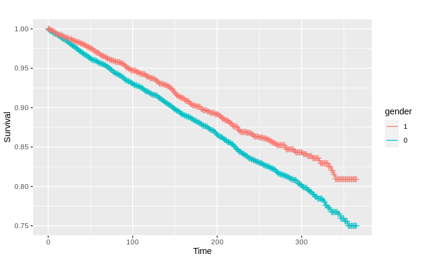

```r
ggsurv(km.by.gender)
```

Let’s improve the graph:

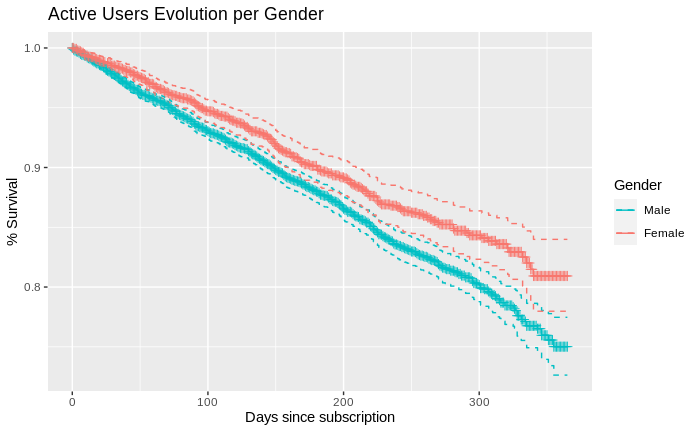

```r
g2 <- ggsurv(km.by.gender, CI=TRUE, xlab = 'Days since subscription', ylab = '% Survival', main='Active Users Evolution per Gender')
g2 <- g2 +
      ggplot2::guides(linetype = FALSE) +
      ggplot2::scale_color_discrete(name='Gender', breaks = c(0,1), labels = c('Male', 'Female'))
g2
```

**Question: what is happening?**

One last graph:

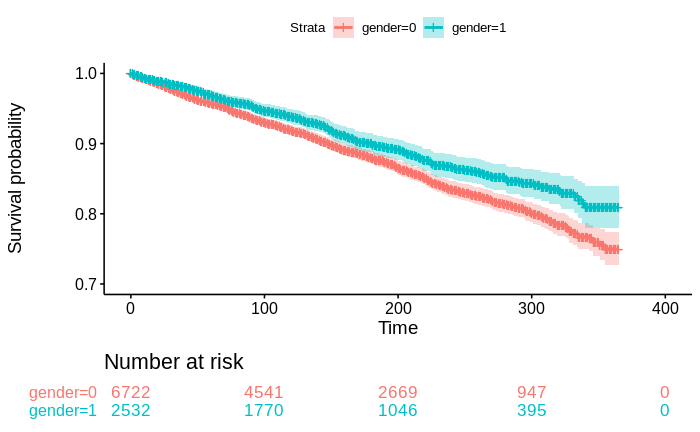

```r
ggsurvplot(km.by.gender, data = df,risk.table = TRUE, size = 1,
           tables.height = 0.2, risk.table.col="strata",
           tables.theme = theme_cleantable(), ylim = c(0.7,1), conf.int = TRUE)
```

# Predicting churn

## Case

- A telecommunications company and involves customer data for a collection of customers who either stayed with the company or left within a certain period.
- In many industries its often not the case that the cut off is so binary. Frequently it might be more likely that a client account lays dormant rather then getting explicitly closed - for example if the client only pays for usage.
- We need to predict customer churn.
- We will use random forest algorithm.

## Load packages

```r
install.packages("randomForest")
```

## Prepare the data

|  | State | Account.Length | Area.Code | Phone | Int.l.Plan | VMail.Plan | VMail.Message | Day.Mins | Day.Calls | Day.Charge | Eve.Mins | Eve.Calls | Eve.Charge | Night.Mins | Night.Calls | Night.Charge | Intl.Mins | Intl.Calls | Intl.Charge | CustServ.Calls | Churned |
| --- | --- | --- | --- | --- | --- | --- | --- | --- | --- | --- | --- | --- | --- | --- | --- | --- | --- | --- | --- | --- | --- |
| 1 | KS | 128 | 415 | 382-4657 | no | yes | 25 | 265.1 | 110 | 45.07 | 197.4 | 99 | 16.78 | 244.7 | 91 | 11.01 | 10.0 | 3 | 2.70 | 1 | False. |
| 3 | NJ | 137 | 415 | 358-1921 | no | no | 0 | 243.4 | 114 | 41.38 | 121.2 | 110 | 10.30 | 162.6 | 104 | 7.32 | 12.2 | 5 | 3.29 | 0 | False. |
| 4 | OH | 84 | 408 | 375-9999 | yes | no | 0 | 299.4 | 71 | 50.90 | 61.9 | 88 | 5.26 | 196.9 | 89 | 8.86 | 6.6 | 7 | 1.78 | 2 | False. |
| 6 | AL | 118 | 510 | 391-8027 | yes | no | 0 | 223.4 | 98 | 37.98 | 220.6 | 101 | 18.75 | 203.9 | 118 | 9.18 | 6.3 | 6 | 1.70 | 0 | False. |
| 7 | MA | 121 | 510 | 355-9993 | no | yes | 24 | 218.2 | 88 | 37.09 | 348.5 | 108 | 29.62 | 212.6 | 118 | 9.57 | 7.5 | 7 | 2.03 | 3 | False. |
| 8 | MO | 147 | 415 | 329-9001 | yes | no | 0 | 157.0 | 79 | 26.69 | 103.1 | 94 | 8.76 | 211.8 | 96 | 9.53 | 7.1 | 6 | 1.92 | 0 | False. |
| 10 | WV | 141 | 415 | 330-8173 | yes | yes | 37 | 258.6 | 84 | 43.96 | 222.0 | 111 | 18.87 | 326.4 | 97 | 14.69 | 11.2 | 5 | 3.02 | 0 | False. |
| 12 | RI | 74 | 415 | 344-9403 | no | no | 0 | 187.7 | 127 | 31.91 | 163.4 | 148 | 13.89 | 196.0 | 94 | 8.82 | 9.1 | 5 | 2.46 | 0 | False. |
| 15 | IA | 62 | 415 | 366-9238 | no | no | 0 | 120.7 | 70 | 20.52 | 307.2 | 76 | 26.11 | 203.0 | 99 | 9.14 | 13.1 | 6 | 3.54 | 4 | False. |
| 18 | VT | 93 | 510 | 386-2923 | no | no | 0 | 190.7 | 114 | 32.42 | 218.2 | 111 | 18.55 | 129.6 | 121 | 5.83 | 8.1 | 3 | 2.19 | 3 | False. |

[output cut: 65 more lines]

Let’s have a look on our training data set at the balance: how many clients has an existing contract with our telecommunications company or they have cancelled it.

```r
prop.table(table(churnTrain$Churned))
```

```
   False.     True.
0.8547558 0.1452442
```

So we can see: about ~15% of customers left our service.

## EDA

We need to avoid missing data (ignore, impute or delete), errors (what can we do) or low or high variance (outliers).

```r
summary(churnTrain)
```

```
    State           Account.Length    Area.Code        Phone            Int.l.Plan
 Length:2334        Min.   :  1.0   Min.   :408.0   Length:2334        Length:2334
 Class :character   1st Qu.: 73.0   1st Qu.:415.0   Class :character   Class :character
 Mode  :character   Median :100.0   Median :415.0   Mode  :character   Mode  :character
  VMail.Plan        VMail.Message       Day.Mins       Day.Calls       Day.Charge       Eve.Mins
 Length:2334        Min.   : 0.000   Min.   :  0.0   Min.   :  0.0   Min.   : 0.00   Min.   :  0.0
 Class :character   1st Qu.: 0.000   1st Qu.:143.6   1st Qu.: 87.0   1st Qu.:24.41   1st Qu.:167.6
 Mode  :character   Median : 0.000   Median :179.3   Median :100.0   Median :30.48   Median :201.4
   Eve.Calls       Eve.Charge      Night.Mins     Night.Calls     Night.Charge      Intl.Mins
 Min.   :  0.0   Min.   : 0.00   Min.   : 23.2   Min.   : 36.0   Min.   : 1.040   Min.   : 0.00
 1st Qu.: 87.0   1st Qu.:14.25   1st Qu.:166.3   1st Qu.: 87.0   1st Qu.: 7.480   1st Qu.: 8.60
 Median :101.0   Median :17.12   Median :201.4   Median :101.0   Median : 9.060   Median :10.30
   Intl.Calls      Intl.Charge    CustServ.Calls    Churned
 Min.   : 0.000   Min.   :0.000   Min.   :0.000   Length:2334
 1st Qu.: 3.000   1st Qu.:2.320   1st Qu.:1.000   Class :character
 Median : 4.000   Median :2.780   Median :1.000   Mode  :character
 [ reached getOption("max.print") -- omitted 3 rows ]
```

```r
churnTrain$Phone <- NULL
churnTest$Phone <- NULL
churnTrain$Area.Code <- as.factor(churnTrain$Area.Code)
churnTest$Area.Code <- as.factor(churnTest$Area.Code)
```

The next step is to have a close look at the variables graphically.

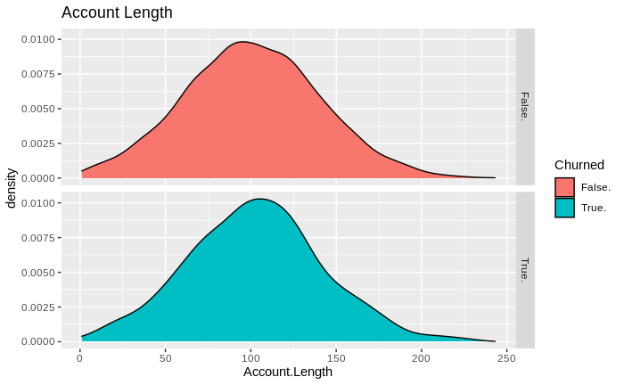

```r
one <- ggplot(churn, aes(x=Account.Length, fill=Churned))+geom_density()+ facet_grid(Churned ~ .) + labs(title="Account Length")
one
```

Does not appear to be any noticable difference (in general we need to repeat this operation for all the variables).

## Building the model

```r
fitControl <- trainControl(method = "cv",
                           number = 5,
                           verboseIter = TRUE)
```

Now we can execute our model:

```r
model <- train(
  Churned ~ .,
  tuneLength = 3,
  data = churnTrain,
  method = "rf",
  trControl = fitControl
)
```

How performs the model agains the training data set:

```r
confusionMatrix(model)
```

[output not shown]

Let’s review how it works against the test data set.

```r
pred <- predict(model, newdata=churnTest)
confusionMatrix(pred, churnTest$Churned)
```

[output not shown]

**Question: What can we observe?**

```r
plot(model)
```

[output not shown]